# MVA_Assignment4

Akshita

2024-02-29

1. Decide how many Principal Components (PCs) you want to keep and why.

```r
library(readr)
fish <- read_csv("C:/Users/HP/Desktop/USA/Spring'24/Multivariate/Datasets/Fish_dataset.csv")
str(fish)
```

```
## spc_tbl_ [158 × 7] (S3: spec_tbl_df/tbl_df/tbl/data.frame)
##  $ Species: chr [1:158] "Bream" "Bream" "Bream" "Bream" ...
##  $ Weight : num [1:158] 242 290 340 363 430 450 500 390 450 500 ...
##  $ Length1: num [1:158] 23.2 24 23.9 26.3 26.5 26.8 26.8 27.6 27.6 28.5 ...
##  $ Length2: num [1:158] 25.4 26.3 26.5 29 29 29.7 29.7 30 30 30.7 ...
##  $ Length3: num [1:158] 30 31.2 31.1 33.5 34 34.7 34.5 35 35.1 36.2 ...
##  $ Height : num [1:158] 11.5 12.5 12.4 12.7 12.4 ...
##  $ Width  : num [1:158] 4.02 4.31 4.7 4.46 5.13 ...
##  - attr(*, "spec")=
##   .. cols(
##   ..   Species = col_character(),
##   ..   Weight = col_double(),
##   ..   Length1 = col_double(),
##   ..   Length2 = col_double(),
##   ..   Length3 = col_double(),
##   ..   Height = col_double(),
##   ..   Width = col_double()
##   .. )
##  - attr(*, "problems")=<externalptr>
```

```r
attach(fish)

#Get the Correlations between the measurements
cor(fish[-1])
```

```
##            Weight   Length1   Length2   Length3    Height     Width
## Weight  1.0000000 0.9157195 0.9186031 0.9230903 0.7238573 0.8866536
## Length1 0.9157195 1.0000000 0.9995162 0.9920042 0.6244087 0.8666843
## Length2 0.9186031 0.9995162 1.0000000 0.9940830 0.6395032 0.8732011
## Length3 0.9230903 0.9920042 0.9940830 1.0000000 0.7026548 0.8781887
## Height  0.7238573 0.6244087 0.6395032 0.7026548 1.0000000 0.7924005
## Width   0.8866536 0.8666843 0.8732011 0.8781887 0.7924005 1.0000000
```

```r
fish_pca <- prcomp(fish[,-1],scale=TRUE)
fish_pca
```

```
## Standard deviations (1, .., p=6):
## [1] 2.29530871 0.71538652 0.34733807 0.31189605 0.03974234 0.01666500
##
## Rotation (n x k) = (6 x 6):
##               PC1         PC2        PC3         PC4         PC5          PC6
## Weight  0.4174145 -0.03934572  0.2195906  0.88064340  0.02130717  0.003194724
## Length1 0.4215573 -0.33510472 -0.1659288 -0.15960339 -0.47183600 -0.659059494
## Length2 0.4234438 -0.30863947 -0.1721405 -0.16629765 -0.33015927  0.747759733
## Length3 0.4276972 -0.19677220 -0.3322752 -0.14772533  0.79986934 -0.079594435
## Height  0.3425075  0.84288953 -0.3890823 -0.02421089 -0.14226749 -0.003821636
## Width   0.4105041  0.20424583  0.7955020 -0.38591465  0.08877305 -0.011656740
```

```r
summary(fish_pca)
```

```
## Importance of components:
##                           PC1    PC2     PC3     PC4     PC5     PC6
## Standard deviation     2.2953 0.7154 0.34734 0.31190 0.03974 0.01666
## Proportion of Variance 0.8781 0.0853 0.02011 0.01621 0.00026 0.00005
## Cumulative Proportion  0.8781 0.9634 0.98348 0.99969 0.99995 1.00000
```

2. Explain the variate representation each PCs.

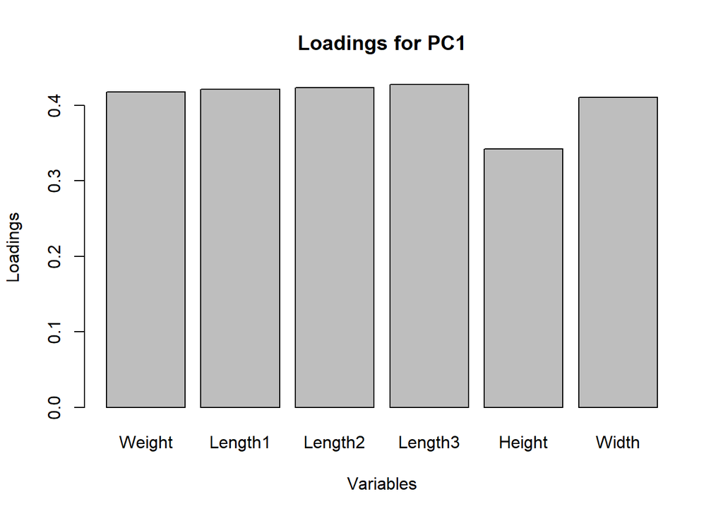

```r
loadings <- fish_pca$rotation
barplot(loadings[, 1], main = "Loadings for PC1", xlab = "Variables", ylab = "Loadings")
```

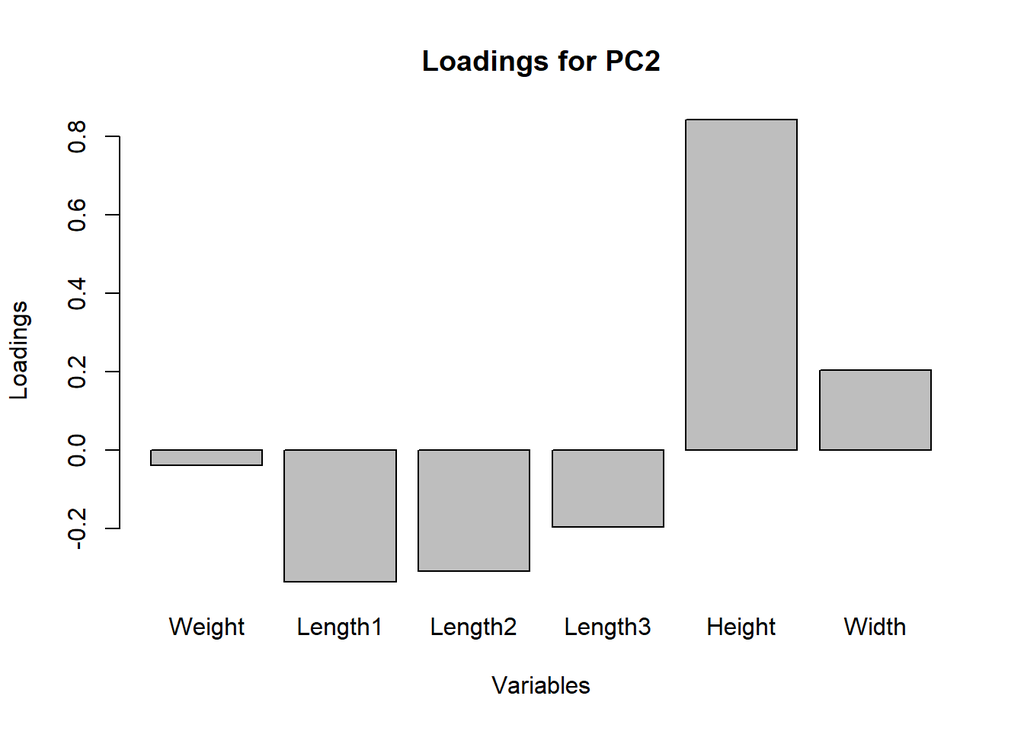

```r
barplot(loadings[, 2], main = "Loadings for PC2", xlab = "Variables", ylab = "Loadings")
```

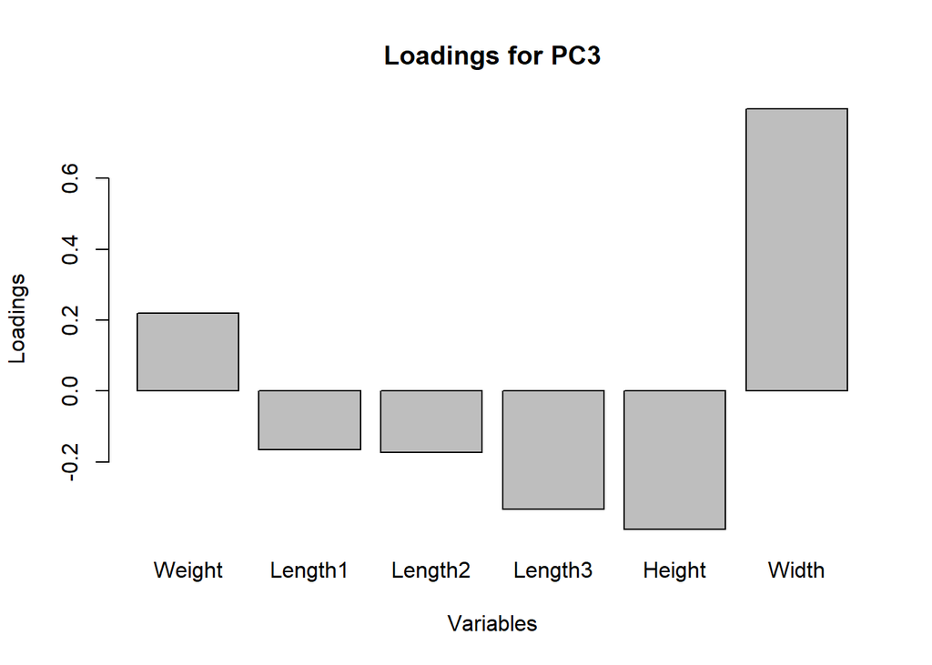

```r
barplot(loadings[, 3], main = "Loadings for PC3", xlab = "Variables", ylab = "Loadings")
```

For PC1, all the variables have high positive loadings which means they contribute most to the overall variation in the dataset captured by PC1. These variables are the primary drivers of the patterns observed in the data along PC1.

For PC2, Length1, Length2 have high negative loadings including Height with a high positive loading.

For PC3, Height and Width have relatively high negative and positive loadings, respectively which means they are the primary drivers of the patterns observed in the data along PC3.

```r
(eigen_fish <- fish_pca$sdev^2)
```

```
## [1] 5.2684420705 0.5117778753 0.1206437330 0.0972791457 0.0015794534
## [6] 0.0002777221
```

```r
names(eigen_fish) <- paste("PC",1:6,sep="")
eigen_fish
```

```
##          PC1          PC2          PC3          PC4          PC5          PC6
## 5.2684420705 0.5117778753 0.1206437330 0.0972791457 0.0015794534 0.0002777221
```

```r
sumlambdas <- sum(eigen_fish)
sumlambdas
```

```
## [1] 6
```

```r
propvar <- eigen_fish/sumlambdas
propvar
```

```
##          PC1          PC2          PC3          PC4          PC5          PC6
## 8.780737e-01 8.529631e-02 2.010729e-02 1.621319e-02 2.632422e-04 4.628702e-05
```

```r
cumvar_fish <- cumsum(propvar)
cumvar_fish
```

```
##       PC1       PC2       PC3       PC4       PC5       PC6
## 0.8780737 0.9633700 0.9834773 0.9996905 0.9999537 1.0000000
```

```r
matlambdas <- rbind(eigen_fish,propvar,cumvar_fish)
rownames(matlambdas) <- c("Eigenvalues","Prop. variance","Cum. prop. variance")
round(matlambdas,4)
```

```
##                        PC1    PC2    PC3    PC4    PC5   PC6
## Eigenvalues         5.2684 0.5118 0.1206 0.0973 0.0016 3e-04
## Prop. variance      0.8781 0.0853 0.0201 0.0162 0.0003 0e+00
## Cum. prop. variance 0.8781 0.9634 0.9835 0.9997 1.0000 1e+00
```

```r
summary(fish_pca)
```

```
## Importance of components:
##                           PC1    PC2     PC3     PC4     PC5     PC6
## Standard deviation     2.2953 0.7154 0.34734 0.31190 0.03974 0.01666
## Proportion of Variance 0.8781 0.0853 0.02011 0.01621 0.00026 0.00005
## Cumulative Proportion  0.8781 0.9634 0.98348 0.99969 0.99995 1.00000
```

```r
fish_pca$rotation
```

```
##               PC1         PC2        PC3         PC4         PC5          PC6
## Weight  0.4174145 -0.03934572  0.2195906  0.88064340  0.02130717  0.003194724
## Length1 0.4215573 -0.33510472 -0.1659288 -0.15960339 -0.47183600 -0.659059494
## Length2 0.4234438 -0.30863947 -0.1721405 -0.16629765 -0.33015927  0.747759733
## Length3 0.4276972 -0.19677220 -0.3322752 -0.14772533  0.79986934 -0.079594435
## Height  0.3425075  0.84288953 -0.3890823 -0.02421089 -0.14226749 -0.003821636
## Width   0.4105041  0.20424583  0.7955020 -0.38591465  0.08877305 -0.011656740
```

```r
print(fish_pca)
```

```
## Standard deviations (1, .., p=6):
## [1] 2.29530871 0.71538652 0.34733807 0.31189605 0.03974234 0.01666500
##
## Rotation (n x k) = (6 x 6):
##               PC1         PC2        PC3         PC4         PC5          PC6
## Weight  0.4174145 -0.03934572  0.2195906  0.88064340  0.02130717  0.003194724
## Length1 0.4215573 -0.33510472 -0.1659288 -0.15960339 -0.47183600 -0.659059494
## Length2 0.4234438 -0.30863947 -0.1721405 -0.16629765 -0.33015927  0.747759733
## Length3 0.4276972 -0.19677220 -0.3322752 -0.14772533  0.79986934 -0.079594435
## Height  0.3425075  0.84288953 -0.3890823 -0.02421089 -0.14226749 -0.003821636
## Width   0.4105041  0.20424583  0.7955020 -0.38591465  0.08877305 -0.011656740
```

```r
## Sample scores stored in fish_pca$x
fish_pca$x
```

```
##                PC1          PC2          PC3           PC4           PC5
##   [1,] -0.37991489  0.679078709 -0.380347240 -0.1999123694  0.0374010916
##   [2,] -0.06459845  0.823757274 -0.365315416 -0.1943499950  0.0406301472
##   [3,]  0.08051045  0.844711001 -0.140135115 -0.1601333002  0.0591989735
##   [4,]  0.36493940  0.689354869 -0.419700923 -0.1580116323  0.0113313550
##   [5,]  0.61203712  0.692753019 -0.050700337 -0.1560154819  0.0854261784
##   [6,]  0.74353678  0.850875066 -0.276866539 -0.0906234869  0.0498687515
##   [7,]  0.92587955  1.004467303 -0.127369591 -0.0484580517  0.0384275649
##   [8,]  0.59802786  0.605310015 -0.367695093 -0.2000577197  0.0384044814
##   [9,]  0.81555091  0.877577543 -0.382203585 -0.0962752247  0.0127259632
##  [10,]  1.02565116  0.860691405 -0.374724143 -0.0400092723  0.0261543712
##  [11,]  1.04218336  0.882774715 -0.328306604 -0.1379020216  0.0265602459
##  [12,]  1.02226372  0.856274538 -0.464166778 -0.0155779378 -0.0049077454
##  [13,]  0.90883033  0.650977260 -0.639418220  0.0732488580 -0.0285793071
##  [14,]  0.97534897  0.740968590 -0.459981934 -0.5081294679  0.0215198775
```

[output cut: 303 more lines]

```r
# Identifying the scores by their survival status
fishtype_pca <- cbind(data.frame(Species),fish_pca$x)
fishtype_pca
```

```
##       Species         PC1          PC2          PC3           PC4           PC5
## 1       Bream -0.37991489  0.679078709 -0.380347240 -0.1999123694  0.0374010916
## 2       Bream -0.06459845  0.823757274 -0.365315416 -0.1943499950  0.0406301472
## 3       Bream  0.08051045  0.844711001 -0.140135115 -0.1601333002  0.0591989735
## 4       Bream  0.36493940  0.689354869 -0.419700923 -0.1580116323  0.0113313550
## 5       Bream  0.61203712  0.692753019 -0.050700337 -0.1560154819  0.0854261784
## 6       Bream  0.74353678  0.850875066 -0.276866539 -0.0906234869  0.0498687515
## 7       Bream  0.92587955  1.004467303 -0.127369591 -0.0484580517  0.0384275649
## 8       Bream  0.59802786  0.605310015 -0.367695093 -0.2000577197  0.0384044814
## 9       Bream  0.81555091  0.877577543 -0.382203585 -0.0962752247  0.0127259632
## 10      Bream  1.02565116  0.860691405 -0.374724143 -0.0400092723  0.0261543712
## 11      Bream  1.04218336  0.882774715 -0.328306604 -0.1379020216  0.0265602459
## 12      Bream  1.02226372  0.856274538 -0.464166778 -0.0155779378 -0.0049077454
## 13      Bream  0.90883033  0.650977260 -0.639418220  0.0732488580 -0.0285793071
## 14      Bream  0.97534897  0.740968590 -0.459981934 -0.5081294679  0.0215198775
```

[output cut: 303 more lines]

```r
tabmeansPC <- aggregate(fishtype_pca[,2:7],by=list(Species=fish$Species),mean)
tabmeansPC
```

```
##     Species        PC1         PC2         PC3         PC4          PC5
## 1     Bream  1.6035408  0.92590832 -0.29864537  0.04422987  0.015089065
## 2    Parkki -1.5327999  0.50719471 -0.21741453  0.02370379 -0.054704106
## 3     Perch -0.1422170 -0.11577757  0.30915970 -0.07345297 -0.020616885
## 4      Pike  2.4246078 -1.53088179 -0.41715414 -0.10477693  0.009189043
## 5     Roach -1.3478686 -0.04538355  0.07243051 -0.14668561  0.045214851
## 6     Smelt -3.7017649 -0.37224733 -0.04192215  0.51139662  0.001736540
## 7 Whitefish  0.8194844  0.09939193  0.30559253 -0.04778984  0.031427663
##             PC6
## 1  0.0004150927
## 2 -0.0035048941
## 3  0.0070803399
## 4  0.0003426168
## 5 -0.0112665740
## 6 -0.0142247507
## 7  0.0058189148
```

```r
tabmeansPC <- tabmeansPC[rev(order(tabmeansPC$Species)),]
tabmeansPC
```

```
##     Species        PC1         PC2         PC3         PC4          PC5
## 7 Whitefish  0.8194844  0.09939193  0.30559253 -0.04778984  0.031427663
## 6     Smelt -3.7017649 -0.37224733 -0.04192215  0.51139662  0.001736540
## 5     Roach -1.3478686 -0.04538355  0.07243051 -0.14668561  0.045214851
## 4      Pike  2.4246078 -1.53088179 -0.41715414 -0.10477693  0.009189043
## 3     Perch -0.1422170 -0.11577757  0.30915970 -0.07345297 -0.020616885
## 2    Parkki -1.5327999  0.50719471 -0.21741453  0.02370379 -0.054704106
## 1     Bream  1.6035408  0.92590832 -0.29864537  0.04422987  0.015089065
##             PC6
## 7  0.0058189148
## 6 -0.0142247507
## 5 -0.0112665740
## 4  0.0003426168
## 3  0.0070803399
## 2 -0.0035048941
## 1  0.0004150927
```

```r
tabfmeans <- t(tabmeansPC[,-1])
tabfmeans
```

```
##                7           6           5             4           3            2
## PC1  0.819484398 -3.70176494 -1.34786863  2.4246077957 -0.14221703 -1.532799883
## PC2  0.099391934 -0.37224733 -0.04538355 -1.5308817865 -0.11577757  0.507194713
## PC3  0.305592533 -0.04192215  0.07243051 -0.4171541399  0.30915970 -0.217414532
## PC4 -0.047789839  0.51139662 -0.14668561 -0.1047769265 -0.07345297  0.023703792
## PC5  0.031427663  0.00173654  0.04521485  0.0091890434 -0.02061688 -0.054704106
## PC6  0.005818915 -0.01422475 -0.01126657  0.0003426168  0.00708034 -0.003504894
##                 1
## PC1  1.6035407538
## PC2  0.9259083200
## PC3 -0.2986453665
## PC4  0.0442298702
## PC5  0.0150890650
## PC6  0.0004150927
```

```r
colnames(tabfmeans) <- t(as.vector(tabmeansPC[1]$Species))
tabfmeans
```

```
##        Whitefish       Smelt       Roach          Pike       Perch       Parkki
## PC1  0.819484398 -3.70176494 -1.34786863  2.4246077957 -0.14221703 -1.532799883
## PC2  0.099391934 -0.37224733 -0.04538355 -1.5308817865 -0.11577757  0.507194713
## PC3  0.305592533 -0.04192215  0.07243051 -0.4171541399  0.30915970 -0.217414532
## PC4 -0.047789839  0.51139662 -0.14668561 -0.1047769265 -0.07345297  0.023703792
## PC5  0.031427663  0.00173654  0.04521485  0.0091890434 -0.02061688 -0.054704106
## PC6  0.005818915 -0.01422475 -0.01126657  0.0003426168  0.00708034 -0.003504894
##             Bream
## PC1  1.6035407538
## PC2  0.9259083200
## PC3 -0.2986453665
## PC4  0.0442298702
## PC5  0.0150890650
## PC6  0.0004150927
```

```r
tabsdsPC <- aggregate(fishtype_pca[,2:7],by=list(Species=fish$Species),sd)
tabfsds <- t(tabsdsPC[,-1])
colnames(tabfsds) <- t(as.vector(tabsdsPC[1]$Species))
tabfsds
```

```
##          Bream      Parkki      Perch       Pike      Roach      Smelt
## PC1 1.01140974 0.795853083 2.11273512 2.09428765 0.80794917 0.25270509
## PC2 0.18375856 0.117872650 0.12579461 0.38986454 0.08980565 0.03902624
## PC3 0.13921559 0.070367211 0.28258189 0.18367601 0.09212138 0.07221399
## PC4 0.21428937 0.126980860 0.21603368 0.58063511 0.14070822 0.11149695
## PC5 0.03335025 0.013036494 0.02827935 0.05075917 0.02170734 0.01078729
## PC6 0.01577757 0.002034505 0.01795887 0.01264587 0.01415834 0.01055954
##      Whitefish
## PC1 1.44713723
## PC2 0.16078862
## PC3 0.29780140
## PC4 0.29118156
## PC5 0.02153355
## PC6 0.01639448
```

```r
# univariate
# Define the principal components and species of interest
pcs_of_interest <- c("PC1", "PC2", "PC3", "PC4", "PC5", "PC6")
species_of_interest <- c("Bream", "Roach", "Whitefish", "Parkki", "Perch", "Pike")

# Create an empty list to store the results
t_test_results <- list()

# Loop through each principal component
for (pc in pcs_of_interest) {
  # Perform the Welch's two-sample t-test for the current principal component
  t_test_result <- list()
  for (i in 1:(length(species_of_interest) - 1)) {
    for (j in (i+1):length(species_of_interest)) {
      species1 <- species_of_interest[i]
      species2 <- species_of_interest[j]
      subset_data1 <- subset(fishtype_pca, Species == species1)
      subset_data2 <- subset(fishtype_pca, Species == species2)
      t_test_result[[paste(species1, species2, sep = "_")]] <- t.test(subset_data1[[pc]], subset_data2[[pc]], var.equal = FALSE)
    }
  }

  # Store the t-test results in the list
  t_test_results[[pc]] <- t_test_result
}

# Access the results for a specific principal component, e.g., PC1
t_test_results[["PC1"]]
```

```
## $Bream_Roach
##
##  Welch Two Sample t-test
##
## data:  subset_data1[[pc]] and subset_data2[[pc]]
## t = 11.705, df = 44.574, p-value = 3.459e-15
## alternative hypothesis: true difference in means is not equal to 0
## 95 percent confidence interval:
##  2.443401 3.459417
## sample estimates:
## mean of x mean of y
##  1.603541 -1.347869
##
##
## $Bream_Whitefish
##
##  Welch Two Sample t-test
##
## data:  subset_data1[[pc]] and subset_data2[[pc]]
## t = 1.2748, df = 5.8664, p-value = 0.2505
## alternative hypothesis: true difference in means is not equal to 0
## 95 percent confidence interval:
##  -0.7292152  2.2973279
## sample estimates:
## mean of x mean of y
## 1.6035408 0.8194844
##
##
## $Bream_Parkki
##
##  Welch Two Sample t-test
##
## data:  subset_data1[[pc]] and subset_data2[[pc]]
## t = 10.645, df = 21.127, p-value = 6e-10
## alternative hypothesis: true difference in means is not equal to 0
## 95 percent confidence interval:
##  2.523847 3.748834
## sample estimates:
## mean of x mean of y
##  1.603541 -1.532800
```

[output cut: 153 more lines]

```
## -1.532800  2.424608
##
##
## $Perch_Pike
##
##  Welch Two Sample t-test
##
## data:  subset_data1[[pc]] and subset_data2[[pc]]
## t = -4.417, df = 26.673, p-value = 0.0001492
## alternative hypothesis: true difference in means is not equal to 0
## 95 percent confidence interval:
##  -3.759887 -1.373762
## sample estimates:
## mean of x mean of y
## -0.142217  2.424608
```

```r
t_test_results[["PC2"]]
```

```
## $Bream_Roach
##
##  Welch Two Sample t-test
##
## data:  subset_data1[[pc]] and subset_data2[[pc]]
## t = 26.059, df = 51.624, p-value < 2.2e-16
## alternative hypothesis: true difference in means is not equal to 0
## 95 percent confidence interval:
##  0.8964858 1.0460980
## sample estimates:
##   mean of x   mean of y
##  0.92590832 -0.04538355
##
##
## $Bream_Whitefish
##
##  Welch Two Sample t-test
##
## data:  subset_data1[[pc]] and subset_data2[[pc]]
## t = 11.381, df = 7.4349, p-value = 5.719e-06
## alternative hypothesis: true difference in means is not equal to 0
## 95 percent confidence interval:
##  0.6568138 0.9962190
## sample estimates:
##  mean of x  mean of y
## 0.92590832 0.09939193
##
##
## $Bream_Parkki
##
##  Welch Two Sample t-test
##
## data:  subset_data1[[pc]] and subset_data2[[pc]]
## t = 8.871, df = 26.554, p-value = 2.01e-09
## alternative hypothesis: true difference in means is not equal to 0
## 95 percent confidence interval:
##  0.3217905 0.5156367
## sample estimates:
## mean of x mean of y
## 0.9259083 0.5071947
```

[output cut: 153 more lines]

```
##  0.5071947 -1.5308818
##
##
## $Perch_Pike
##
##  Welch Two Sample t-test
##
## data:  subset_data1[[pc]] and subset_data2[[pc]]
## t = 14.735, df = 17.022, p-value = 4.028e-11
## alternative hypothesis: true difference in means is not equal to 0
## 95 percent confidence interval:
##  1.212501 1.617708
## sample estimates:
##  mean of x  mean of y
## -0.1157776 -1.5308818
```

```r
t_test_results[["PC3"]]
```

```
## $Bream_Roach
##
##  Welch Two Sample t-test
##
## data:  subset_data1[[pc]] and subset_data2[[pc]]
## t = -11.732, df = 49.786, p-value = 6.076e-16
## alternative hypothesis: true difference in means is not equal to 0
## 95 percent confidence interval:
##  -0.4346113 -0.3075404
## sample estimates:
##   mean of x   mean of y
## -0.29864537  0.07243051
##
##
## $Bream_Whitefish
##
##  Welch Two Sample t-test
##
## data:  subset_data1[[pc]] and subset_data2[[pc]]
## t = -4.8794, df = 5.3805, p-value = 0.003736
## alternative hypothesis: true difference in means is not equal to 0
## 95 percent confidence interval:
##  -0.9159077 -0.2925681
## sample estimates:
##  mean of x  mean of y
## -0.2986454  0.3055925
##
##
## $Bream_Parkki
##
##  Welch Two Sample t-test
##
## data:  subset_data1[[pc]] and subset_data2[[pc]]
## t = -2.5638, df = 34.417, p-value = 0.01489
## alternative hypothesis: true difference in means is not equal to 0
## 95 percent confidence interval:
##  -0.14559194 -0.01686973
## sample estimates:
##  mean of x  mean of y
## -0.2986454 -0.2174145
```

[output cut: 153 more lines]

```
## -0.2174145 -0.4171541
##
##
## $Perch_Pike
##
##  Welch Two Sample t-test
##
## data:  subset_data1[[pc]] and subset_data2[[pc]]
## t = 12.437, df = 41.083, p-value = 1.631e-15
## alternative hypothesis: true difference in means is not equal to 0
## 95 percent confidence interval:
##  0.6083816 0.8442461
## sample estimates:
##  mean of x  mean of y
##  0.3091597 -0.4171541
```

```r
t_test_results[["PC4"]]
```

```
## $Bream_Roach
##
##  Welch Two Sample t-test
##
## data:  subset_data1[[pc]] and subset_data2[[pc]]
## t = 3.9349, df = 49.945, p-value = 0.0002577
## alternative hypothesis: true difference in means is not equal to 0
## 95 percent confidence interval:
##  0.09346062 0.28837033
## sample estimates:
##   mean of x   mean of y
##  0.04422987 -0.14668561
##
##
## $Bream_Whitefish
##
##  Welch Two Sample t-test
##
## data:  subset_data1[[pc]] and subset_data2[[pc]]
## t = 0.74048, df = 5.964, p-value = 0.4871
## alternative hypothesis: true difference in means is not equal to 0
## 95 percent confidence interval:
##  -0.2125045  0.3965439
## sample estimates:
##   mean of x   mean of y
##  0.04422987 -0.04778984
##
##
## $Bream_Parkki
##
##  Welch Two Sample t-test
##
## data:  subset_data1[[pc]] and subset_data2[[pc]]
## t = 0.38945, df = 29.064, p-value = 0.6998
## alternative hypothesis: true difference in means is not equal to 0
## 95 percent confidence interval:
##  -0.08725765  0.12830981
## sample estimates:
##  mean of x  mean of y
## 0.04422987 0.02370379
```

[output cut: 153 more lines]

```
##  0.02370379 -0.10477693
##
##
## $Perch_Pike
##
##  Welch Two Sample t-test
##
## data:  subset_data1[[pc]] and subset_data2[[pc]]
## t = 0.2179, df = 17.364, p-value = 0.83
## alternative hypothesis: true difference in means is not equal to 0
## 95 percent confidence interval:
##  -0.2714852  0.3341331
## sample estimates:
##   mean of x   mean of y
## -0.07345297 -0.10477693
```

```r
t_test_results[["PC5"]]
```

```
## $Bream_Roach
##
##  Welch Two Sample t-test
##
## data:  subset_data1[[pc]] and subset_data2[[pc]]
## t = -4.0051, df = 50.118, p-value = 0.0002053
## alternative hypothesis: true difference in means is not equal to 0
## 95 percent confidence interval:
##  -0.04523305 -0.01501853
## sample estimates:
##  mean of x  mean of y
## 0.01508907 0.04521485
##
##
## $Bream_Whitefish
##
##  Welch Two Sample t-test
##
## data:  subset_data1[[pc]] and subset_data2[[pc]]
## t = -1.5645, df = 9.7158, p-value = 0.1497
## alternative hypothesis: true difference in means is not equal to 0
## 95 percent confidence interval:
##  -0.039700105  0.007022909
## sample estimates:
##  mean of x  mean of y
## 0.01508907 0.03142766
##
##
## $Bream_Parkki
##
##  Welch Two Sample t-test
##
## data:  subset_data1[[pc]] and subset_data2[[pc]]
## t = 10.156, df = 41.636, p-value = 7.8e-13
## alternative hypothesis: true difference in means is not equal to 0
## 95 percent confidence interval:
##  0.05592075 0.08366560
## sample estimates:
##   mean of x   mean of y
##  0.01508907 -0.05470411
```

[output cut: 153 more lines]

```
## -0.054704106  0.009189043
##
##
## $Perch_Pike
##
##  Welch Two Sample t-test
##
## data:  subset_data1[[pc]] and subset_data2[[pc]]
## t = -2.3145, df = 19.108, p-value = 0.03192
## alternative hypothesis: true difference in means is not equal to 0
## 95 percent confidence interval:
##  -0.056749291 -0.002862566
## sample estimates:
##    mean of x    mean of y
## -0.020616885  0.009189043
```

```r
t_test_results[["PC6"]]
```

```
## $Bream_Roach
##
##  Welch Two Sample t-test
##
## data:  subset_data1[[pc]] and subset_data2[[pc]]
## t = 2.7796, df = 40.665, p-value = 0.008205
## alternative hypothesis: true difference in means is not equal to 0
## 95 percent confidence interval:
##  0.003191992 0.020171341
## sample estimates:
##     mean of x     mean of y
##  0.0004150927 -0.0112665740
##
##
## $Bream_Whitefish
##
##  Welch Two Sample t-test
##
## data:  subset_data1[[pc]] and subset_data2[[pc]]
## t = -0.75003, df = 6.6889, p-value = 0.4788
## alternative hypothesis: true difference in means is not equal to 0
## 95 percent confidence interval:
##  -0.02260234  0.01179470
## sample estimates:
##    mean of x    mean of y
## 0.0004150927 0.0058189148
##
##
## $Bream_Parkki
##
##  Welch Two Sample t-test
##
## data:  subset_data1[[pc]] and subset_data2[[pc]]
## t = 1.4325, df = 37.337, p-value = 0.1603
## alternative hypothesis: true difference in means is not equal to 0
## 95 percent confidence interval:
##  -0.001623071  0.009463044
## sample estimates:
##     mean of x     mean of y
##  0.0004150927 -0.0035048941
```

[output cut: 153 more lines]

```
## -0.0035048941  0.0003426168
##
##
## $Perch_Pike
##
##  Welch Two Sample t-test
##
## data:  subset_data1[[pc]] and subset_data2[[pc]]
## t = 1.7301, df = 37.5, p-value = 0.09183
## alternative hypothesis: true difference in means is not equal to 0
## 95 percent confidence interval:
##  -0.001149506  0.014624952
## sample estimates:
##    mean of x    mean of y
## 0.0070803399 0.0003426168
```

```r
# Levene's tests
library(car)
# Perform Levene's test for homogeneity of variances for PC1
LTPC1 <- leveneTest(PC1 ~ Species, data = fishtype_pca, center = median)
LTPC1
```

```
## Levene's Test for Homogeneity of Variance (center = median)
##        Df F value    Pr(>F)
## group   6  7.6451 3.516e-07 ***
##       151
## ---
## Signif. codes:  0 '***' 0.001 '**' 0.01 '*' 0.05 '.' 0.1 ' ' 1
```

```r
LTPC2 <- leveneTest(PC2 ~ Species, data = fishtype_pca, center = median)
LTPC2
```

```
## Levene's Test for Homogeneity of Variance (center = median)
##        Df F value    Pr(>F)
## group   6   9.633 5.746e-09 ***
##       151
## ---
## Signif. codes:  0 '***' 0.001 '**' 0.01 '*' 0.05 '.' 0.1 ' ' 1
```

```r
LTPC3 <- leveneTest(PC3 ~ Species, data = fishtype_pca, center = median)
LTPC3
```

```
## Levene's Test for Homogeneity of Variance (center = median)
##        Df F value    Pr(>F)
## group   6  4.9167 0.0001274 ***
##       151
## ---
## Signif. codes:  0 '***' 0.001 '**' 0.01 '*' 0.05 '.' 0.1 ' ' 1
```

```r
LTPC4 <- leveneTest(PC4 ~ Species, data = fishtype_pca, center = median)
LTPC4
```

```
## Levene's Test for Homogeneity of Variance (center = median)
##        Df F value   Pr(>F)
## group   6  3.4593 0.003129 **
##       151
## ---
## Signif. codes:  0 '***' 0.001 '**' 0.01 '*' 0.05 '.' 0.1 ' ' 1
```

```r
LTPC5 <- leveneTest(PC5 ~ Species, data = fishtype_pca, center = median)
LTPC5
```

```
## Levene's Test for Homogeneity of Variance (center = median)
##        Df F value    Pr(>F)
## group   6  4.6337 0.0002373 ***
##       151
## ---
## Signif. codes:  0 '***' 0.001 '**' 0.01 '*' 0.05 '.' 0.1 ' ' 1
```

```r
LTPC6 <- leveneTest(PC6 ~ Species, data = fishtype_pca, center = median)
LTPC6
```

```
## Levene's Test for Homogeneity of Variance (center = median)
##        Df F value   Pr(>F)
## group   6  3.6269 0.002169 **
##       151
## ---
## Signif. codes:  0 '***' 0.001 '**' 0.01 '*' 0.05 '.' 0.1 ' ' 1
```

```r
#get the original value of the data based on PCA
center <- fish_pca$center
scale <-fish_pca$scale
new_fish <- as.matrix(fish[,-1])
new_fish
```

```
##        Weight Length1 Length2 Length3  Height  Width
##   [1,]  242.0    23.2    25.4    30.0 11.5200 4.0200
##   [2,]  290.0    24.0    26.3    31.2 12.4800 4.3056
##   [3,]  340.0    23.9    26.5    31.1 12.3778 4.6961
##   [4,]  363.0    26.3    29.0    33.5 12.7300 4.4555
##   [5,]  430.0    26.5    29.0    34.0 12.4440 5.1340
##   [6,]  450.0    26.8    29.7    34.7 13.6024 4.9274
##   [7,]  500.0    26.8    29.7    34.5 14.1795 5.2785
##   [8,]  390.0    27.6    30.0    35.0 12.6700 4.6900
##   [9,]  450.0    27.6    30.0    35.1 14.0049 4.8438
##  [10,]  500.0    28.5    30.7    36.2 14.2266 4.9594
##  [11,]  475.0    28.4    31.0    36.2 14.2628 5.1042
##  [12,]  500.0    28.7    31.0    36.2 14.3714 4.8146
##  [13,]  500.0    29.1    31.5    36.4 13.7592 4.3680
##  [14,]  340.0    29.5    32.0    37.3 13.9129 5.0728
```

[output cut: 144 more lines]

```r
drop(scale(new_fish,center=center, scale=scale)%*%fish_pca$rotation[,1])
```

```
##   [1] -0.37991489 -0.06459845  0.08051045  0.36493940  0.61203712  0.74353678
##   [7]  0.92587955  0.59802786  0.81555091  1.02565116  1.04218336  1.02226372
##  [13]  0.90883033  0.97534897  1.37773596  1.51575293  1.63681390  1.62899488
##  [19]  1.60836918  1.71481876  1.70286681  1.84500169  1.75198352  2.08986096
##  [25]  2.04365255  2.20567894  2.20631842  2.25576388  2.53638172  3.08033383
##  [31]  3.01901782  3.05646301  3.32394326  3.50401876  3.34990931 -3.01655397
##  [37] -2.29217564 -2.14057427 -1.95541626 -1.74725462 -1.72043479 -1.69505081
##  [43] -1.45459797 -1.45500996 -1.28290769 -1.45515483 -1.32412043 -1.03659816
##  [49] -1.18694890 -0.97065742 -0.90179376 -0.39085809 -0.23615190  0.65275555
##  [55] -0.54958213 -0.50525059 -0.13001150  1.11503670  2.14038916  2.84632475
##  [61] -2.70953031 -2.62988278 -2.18234343 -1.85206147 -1.56825016 -1.52554417
##  [67] -1.39389201 -1.35912806 -0.94258171 -0.44582088 -0.25176374 -4.15213711
##  [73] -3.22839646 -2.93641555 -2.67119285 -2.44999395 -2.20153983 -2.21699282
##  [79] -2.13952780 -2.10566869 -2.13447792 -1.73800034 -1.77437708 -1.69315365
##  [85] -1.62911933 -1.61053977 -1.61946085 -1.57031260 -1.58321725 -1.52626924
##  [91] -1.50733181 -1.40935427 -1.45694884 -1.47516846 -1.28434672 -1.08029935
##  [97] -1.22206787 -0.98579313 -1.09212431 -0.86446685 -0.67919083 -0.18424784
## [103] -0.49441645 -0.49779990 -0.44067592 -0.42661468 -0.18674624  0.01648517
## [109]  1.05078248  1.42985675  2.27196774  2.00108952  1.92149214  1.92474050
## [115]  1.91739792  2.71752853  2.06355857  2.69343501  2.71768372  2.80058670
## [121]  3.04070221  2.51938382  3.27302048  3.28172704  3.50217149  3.61143258
## [127]  3.54919077 -0.32502435  0.24198517  0.43358722  0.58900314  1.03872215
## [133]  0.78171108  1.55748868  1.61739672  1.92699701  1.99751844  2.25146463
## [139]  2.84064822  3.78016402  4.96303321  5.56489116  5.50654379  6.45220223
## [145] -4.06395673 -3.93058739 -3.94525887 -3.80540331 -3.80402956 -3.79622870
## [151] -3.71708282 -3.74585443 -3.73520144 -3.66243813 -3.64424942 -3.60950620
## [157] -3.20692877 -3.15798345
```

```r
predict(fish_pca)[,1]
```

```
##   [1] -0.37991489 -0.06459845  0.08051045  0.36493940  0.61203712  0.74353678
##   [7]  0.92587955  0.59802786  0.81555091  1.02565116  1.04218336  1.02226372
##  [13]  0.90883033  0.97534897  1.37773596  1.51575293  1.63681390  1.62899488
##  [19]  1.60836918  1.71481876  1.70286681  1.84500169  1.75198352  2.08986096
##  [25]  2.04365255  2.20567894  2.20631842  2.25576388  2.53638172  3.08033383
##  [31]  3.01901782  3.05646301  3.32394326  3.50401876  3.34990931 -3.01655397
##  [37] -2.29217564 -2.14057427 -1.95541626 -1.74725462 -1.72043479 -1.69505081
##  [43] -1.45459797 -1.45500996 -1.28290769 -1.45515483 -1.32412043 -1.03659816
##  [49] -1.18694890 -0.97065742 -0.90179376 -0.39085809 -0.23615190  0.65275555
##  [55] -0.54958213 -0.50525059 -0.13001150  1.11503670  2.14038916  2.84632475
##  [61] -2.70953031 -2.62988278 -2.18234343 -1.85206147 -1.56825016 -1.52554417
##  [67] -1.39389201 -1.35912806 -0.94258171 -0.44582088 -0.25176374 -4.15213711
##  [73] -3.22839646 -2.93641555 -2.67119285 -2.44999395 -2.20153983 -2.21699282
##  [79] -2.13952780 -2.10566869 -2.13447792 -1.73800034 -1.77437708 -1.69315365
##  [85] -1.62911933 -1.61053977 -1.61946085 -1.57031260 -1.58321725 -1.52626924
##  [91] -1.50733181 -1.40935427 -1.45694884 -1.47516846 -1.28434672 -1.08029935
##  [97] -1.22206787 -0.98579313 -1.09212431 -0.86446685 -0.67919083 -0.18424784
## [103] -0.49441645 -0.49779990 -0.44067592 -0.42661468 -0.18674624  0.01648517
## [109]  1.05078248  1.42985675  2.27196774  2.00108952  1.92149214  1.92474050
## [115]  1.91739792  2.71752853  2.06355857  2.69343501  2.71768372  2.80058670
## [121]  3.04070221  2.51938382  3.27302048  3.28172704  3.50217149  3.61143258
## [127]  3.54919077 -0.32502435  0.24198517  0.43358722  0.58900314  1.03872215
## [133]  0.78171108  1.55748868  1.61739672  1.92699701  1.99751844  2.25146463
## [139]  2.84064822  3.78016402  4.96303321  5.56489116  5.50654379  6.45220223
## [145] -4.06395673 -3.93058739 -3.94525887 -3.80540331 -3.80402956 -3.79622870
## [151] -3.71708282 -3.74585443 -3.73520144 -3.66243813 -3.64424942 -3.60950620
## [157] -3.20692877 -3.15798345
```

3. Perform some visualization using PCs.

```r
fishtype_pca
```

```
##       Species         PC1          PC2          PC3           PC4           PC5
## 1       Bream -0.37991489  0.679078709 -0.380347240 -0.1999123694  0.0374010916
## 2       Bream -0.06459845  0.823757274 -0.365315416 -0.1943499950  0.0406301472
## 3       Bream  0.08051045  0.844711001 -0.140135115 -0.1601333002  0.0591989735
## 4       Bream  0.36493940  0.689354869 -0.419700923 -0.1580116323  0.0113313550
## 5       Bream  0.61203712  0.692753019 -0.050700337 -0.1560154819  0.0854261784
## 6       Bream  0.74353678  0.850875066 -0.276866539 -0.0906234869  0.0498687515
## 7       Bream  0.92587955  1.004467303 -0.127369591 -0.0484580517  0.0384275649
## 8       Bream  0.59802786  0.605310015 -0.367695093 -0.2000577197  0.0384044814
## 9       Bream  0.81555091  0.877577543 -0.382203585 -0.0962752247  0.0127259632
## 10      Bream  1.02565116  0.860691405 -0.374724143 -0.0400092723  0.0261543712
## 11      Bream  1.04218336  0.882774715 -0.328306604 -0.1379020216  0.0265602459
## 12      Bream  1.02226372  0.856274538 -0.464166778 -0.0155779378 -0.0049077454
## 13      Bream  0.90883033  0.650977260 -0.639418220  0.0732488580 -0.0285793071
## 14      Bream  0.97534897  0.740968590 -0.459981934 -0.5081294679  0.0215198775
```

[output cut: 303 more lines]

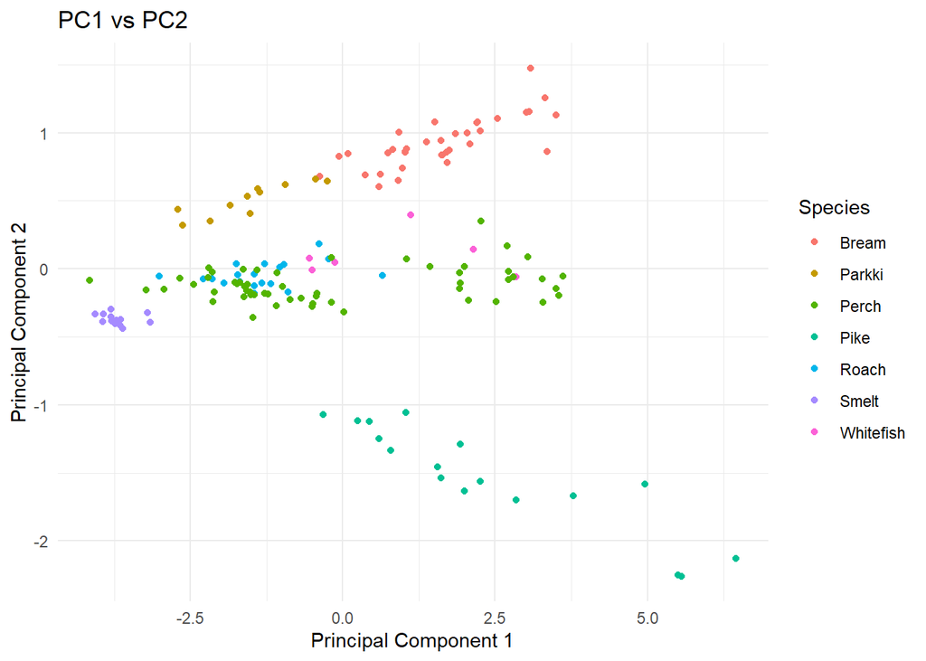

```r
library(ggplot2)
# Plot PC1 against PC2 for each species
ggplot(fishtype_pca, aes(x = PC1, y = PC2, color = Species)) + geom_point() +
labs(x = "Principal Component 1", y = "Principal Component 2", title = "PC1 vs PC2") +
theme_minimal()
```

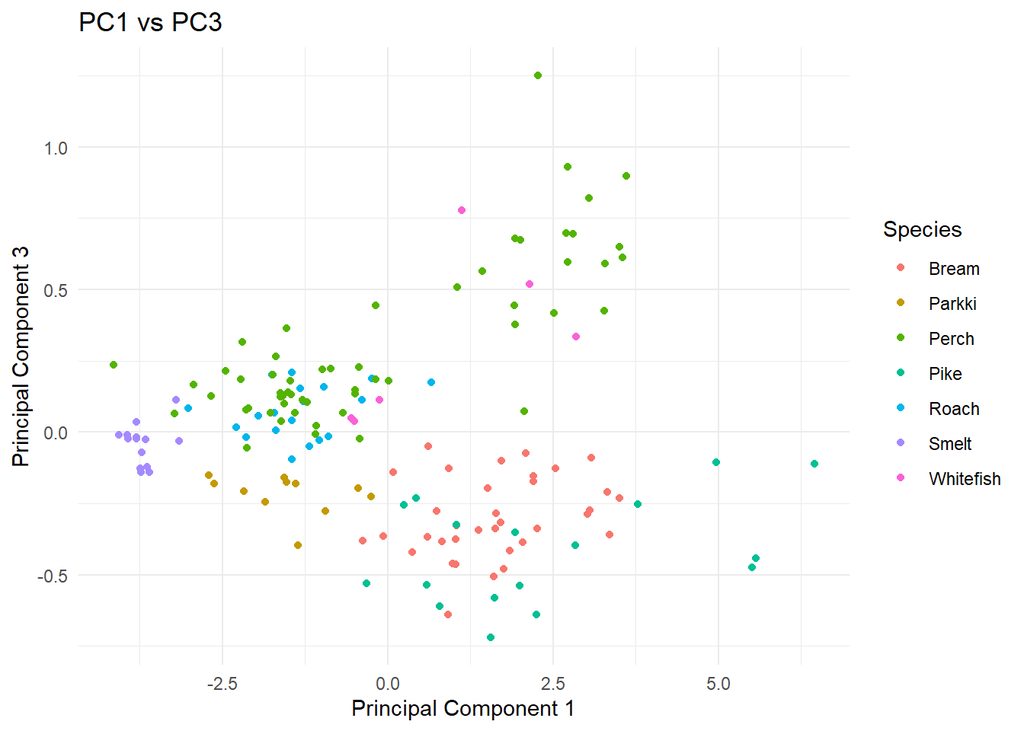

```r
# Plot PC1 against PC3 for each species
ggplot(fishtype_pca, aes(x = PC1, y = PC3, color = Species)) + geom_point() +
labs(x = "Principal Component 1", y = "Principal Component 3", title = "PC1 vs PC3") +
theme_minimal()
```

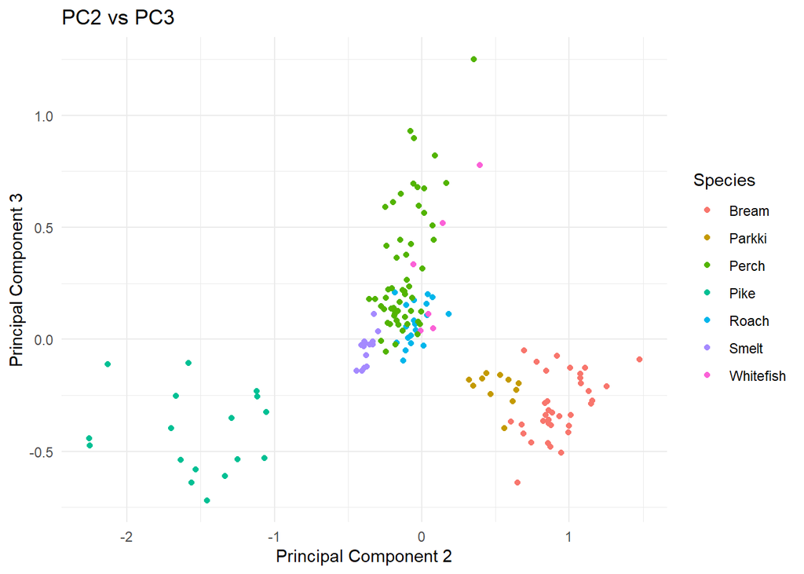

```r
# Plot PC2 against PC3 for each species
ggplot(fishtype_pca, aes(x = PC2, y = PC3, color = Species)) + geom_point() +
labs(x = "Principal Component 2", y = "Principal Component 3", title = "PC2 vs PC3") +
theme_minimal()
```

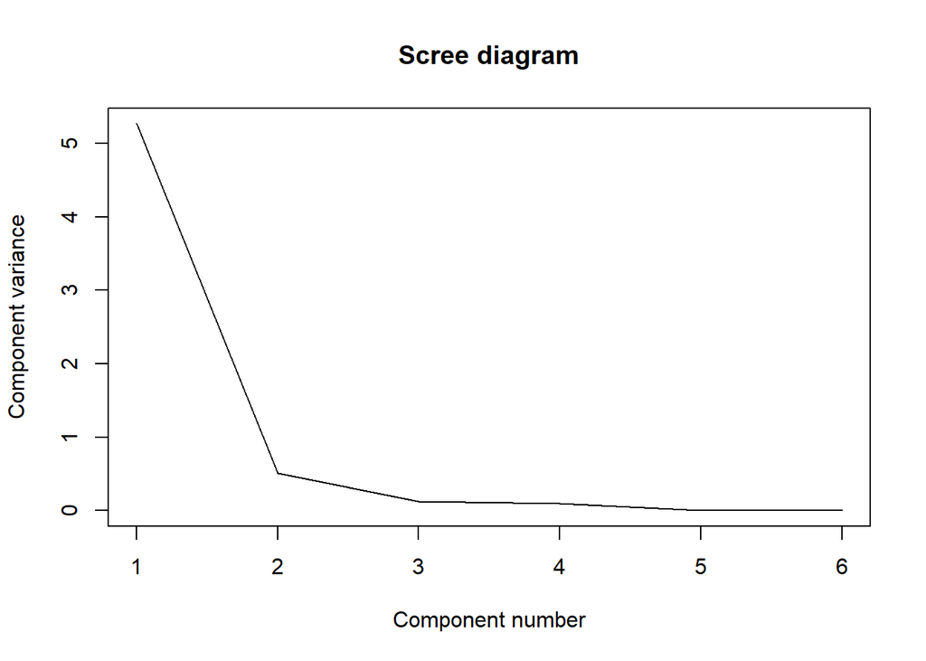

```r
plot(eigen_fish, xlab = "Component number", ylab = "Component variance", type = "l", main = "Scree diagram")
```

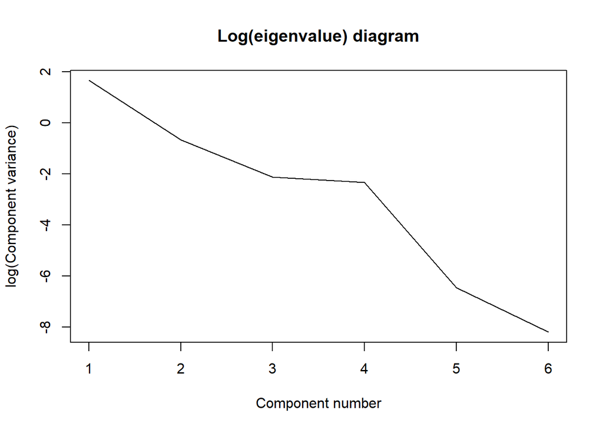

```r
plot(log(eigen_fish), xlab = "Component number",ylab = "log(Component variance)", type="l",main = "Log(eigenvalue) diagram")
```

```r
print(summary(fish_pca))
```

```
## Importance of components:
##                           PC1    PC2     PC3     PC4     PC5     PC6
## Standard deviation     2.2953 0.7154 0.34734 0.31190 0.03974 0.01666
## Proportion of Variance 0.8781 0.0853 0.02011 0.01621 0.00026 0.00005
## Cumulative Proportion  0.8781 0.9634 0.98348 0.99969 0.99995 1.00000
```

```r
diag(cov(fish_pca$x))
```

```
##          PC1          PC2          PC3          PC4          PC5          PC6
## 5.2684420705 0.5117778753 0.1206437330 0.0972791457 0.0015794534 0.0002777221
```

```r
xlim <- range(fish_pca$x[,1])
fish_pca$x[,1]
```

```
##   [1] -0.37991489 -0.06459845  0.08051045  0.36493940  0.61203712  0.74353678
##   [7]  0.92587955  0.59802786  0.81555091  1.02565116  1.04218336  1.02226372
##  [13]  0.90883033  0.97534897  1.37773596  1.51575293  1.63681390  1.62899488
##  [19]  1.60836918  1.71481876  1.70286681  1.84500169  1.75198352  2.08986096
##  [25]  2.04365255  2.20567894  2.20631842  2.25576388  2.53638172  3.08033383
##  [31]  3.01901782  3.05646301  3.32394326  3.50401876  3.34990931 -3.01655397
##  [37] -2.29217564 -2.14057427 -1.95541626 -1.74725462 -1.72043479 -1.69505081
##  [43] -1.45459797 -1.45500996 -1.28290769 -1.45515483 -1.32412043 -1.03659816
##  [49] -1.18694890 -0.97065742 -0.90179376 -0.39085809 -0.23615190  0.65275555
##  [55] -0.54958213 -0.50525059 -0.13001150  1.11503670  2.14038916  2.84632475
##  [61] -2.70953031 -2.62988278 -2.18234343 -1.85206147 -1.56825016 -1.52554417
##  [67] -1.39389201 -1.35912806 -0.94258171 -0.44582088 -0.25176374 -4.15213711
##  [73] -3.22839646 -2.93641555 -2.67119285 -2.44999395 -2.20153983 -2.21699282
##  [79] -2.13952780 -2.10566869 -2.13447792 -1.73800034 -1.77437708 -1.69315365
##  [85] -1.62911933 -1.61053977 -1.61946085 -1.57031260 -1.58321725 -1.52626924
##  [91] -1.50733181 -1.40935427 -1.45694884 -1.47516846 -1.28434672 -1.08029935
##  [97] -1.22206787 -0.98579313 -1.09212431 -0.86446685 -0.67919083 -0.18424784
## [103] -0.49441645 -0.49779990 -0.44067592 -0.42661468 -0.18674624  0.01648517
## [109]  1.05078248  1.42985675  2.27196774  2.00108952  1.92149214  1.92474050
## [115]  1.91739792  2.71752853  2.06355857  2.69343501  2.71768372  2.80058670
## [121]  3.04070221  2.51938382  3.27302048  3.28172704  3.50217149  3.61143258
## [127]  3.54919077 -0.32502435  0.24198517  0.43358722  0.58900314  1.03872215
## [133]  0.78171108  1.55748868  1.61739672  1.92699701  1.99751844  2.25146463
## [139]  2.84064822  3.78016402  4.96303321  5.56489116  5.50654379  6.45220223
## [145] -4.06395673 -3.93058739 -3.94525887 -3.80540331 -3.80402956 -3.79622870
## [151] -3.71708282 -3.74585443 -3.73520144 -3.66243813 -3.64424942 -3.60950620
## [157] -3.20692877 -3.15798345
```

```r
fish_pca$x
```

```
##                PC1          PC2          PC3           PC4           PC5
##   [1,] -0.37991489  0.679078709 -0.380347240 -0.1999123694  0.0374010916
##   [2,] -0.06459845  0.823757274 -0.365315416 -0.1943499950  0.0406301472
##   [3,]  0.08051045  0.844711001 -0.140135115 -0.1601333002  0.0591989735
##   [4,]  0.36493940  0.689354869 -0.419700923 -0.1580116323  0.0113313550
##   [5,]  0.61203712  0.692753019 -0.050700337 -0.1560154819  0.0854261784
##   [6,]  0.74353678  0.850875066 -0.276866539 -0.0906234869  0.0498687515
##   [7,]  0.92587955  1.004467303 -0.127369591 -0.0484580517  0.0384275649
##   [8,]  0.59802786  0.605310015 -0.367695093 -0.2000577197  0.0384044814
##   [9,]  0.81555091  0.877577543 -0.382203585 -0.0962752247  0.0127259632
##  [10,]  1.02565116  0.860691405 -0.374724143 -0.0400092723  0.0261543712
##  [11,]  1.04218336  0.882774715 -0.328306604 -0.1379020216  0.0265602459
##  [12,]  1.02226372  0.856274538 -0.464166778 -0.0155779378 -0.0049077454
##  [13,]  0.90883033  0.650977260 -0.639418220  0.0732488580 -0.0285793071
##  [14,]  0.97534897  0.740968590 -0.459981934 -0.5081294679  0.0215198775
```

[output cut: 303 more lines]

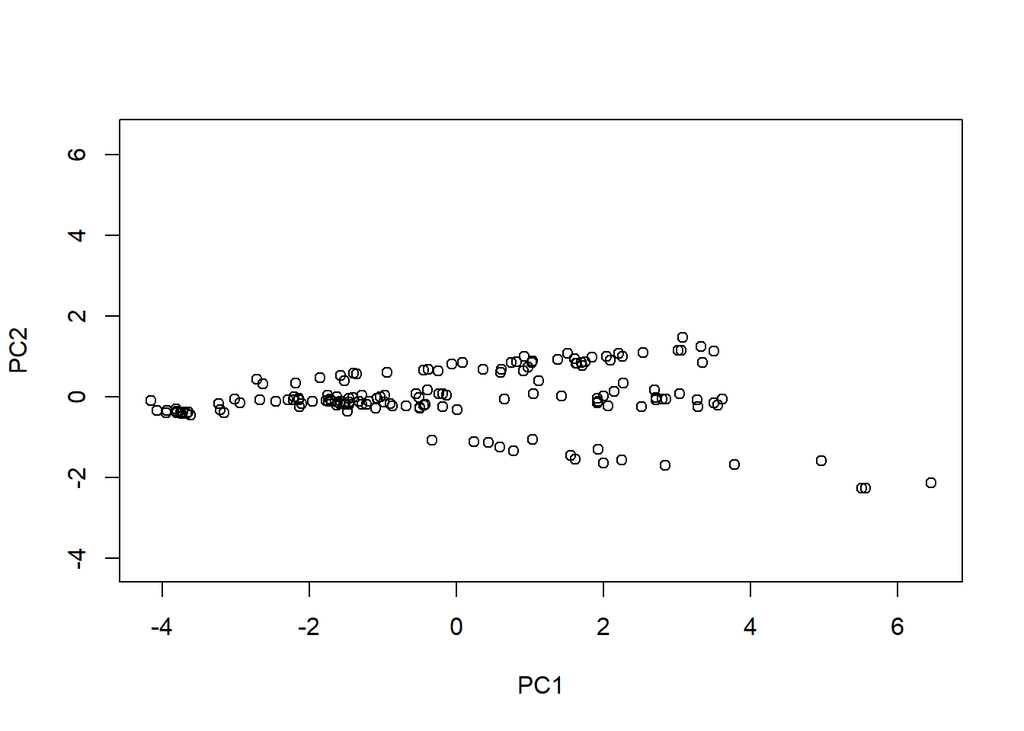

```r
plot(fish_pca$x,xlim=xlim,ylim=xlim)
```

```r
fish_pca$rotation[,1]
```

```
##    Weight   Length1   Length2   Length3    Height     Width
## 0.4174145 0.4215573 0.4234438 0.4276972 0.3425075 0.4105041
```

```r
fish_pca$rotation
```

```
##               PC1         PC2        PC3         PC4         PC5          PC6
## Weight  0.4174145 -0.03934572  0.2195906  0.88064340  0.02130717  0.003194724
## Length1 0.4215573 -0.33510472 -0.1659288 -0.15960339 -0.47183600 -0.659059494
## Length2 0.4234438 -0.30863947 -0.1721405 -0.16629765 -0.33015927  0.747759733
## Length3 0.4276972 -0.19677220 -0.3322752 -0.14772533  0.79986934 -0.079594435
## Height  0.3425075  0.84288953 -0.3890823 -0.02421089 -0.14226749 -0.003821636
## Width   0.4105041  0.20424583  0.7955020 -0.38591465  0.08877305 -0.011656740
```

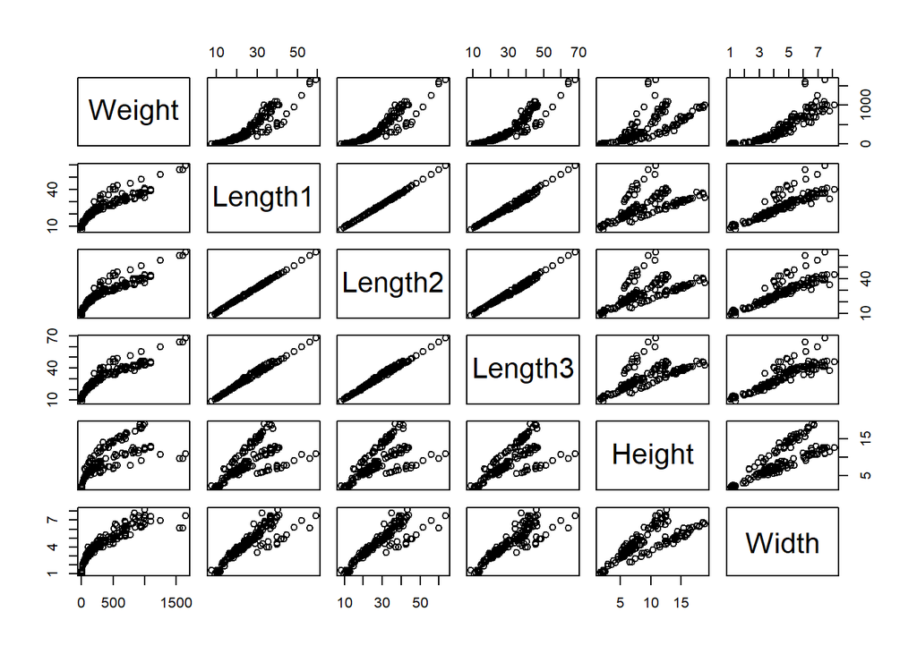

```r
plot(fish[,-1])
```

```r
fish_pca$x
```

```
##                PC1          PC2          PC3           PC4           PC5
##   [1,] -0.37991489  0.679078709 -0.380347240 -0.1999123694  0.0374010916
##   [2,] -0.06459845  0.823757274 -0.365315416 -0.1943499950  0.0406301472
##   [3,]  0.08051045  0.844711001 -0.140135115 -0.1601333002  0.0591989735
##   [4,]  0.36493940  0.689354869 -0.419700923 -0.1580116323  0.0113313550
##   [5,]  0.61203712  0.692753019 -0.050700337 -0.1560154819  0.0854261784
##   [6,]  0.74353678  0.850875066 -0.276866539 -0.0906234869  0.0498687515
##   [7,]  0.92587955  1.004467303 -0.127369591 -0.0484580517  0.0384275649
##   [8,]  0.59802786  0.605310015 -0.367695093 -0.2000577197  0.0384044814
##   [9,]  0.81555091  0.877577543 -0.382203585 -0.0962752247  0.0127259632
##  [10,]  1.02565116  0.860691405 -0.374724143 -0.0400092723  0.0261543712
##  [11,]  1.04218336  0.882774715 -0.328306604 -0.1379020216  0.0265602459
##  [12,]  1.02226372  0.856274538 -0.464166778 -0.0155779378 -0.0049077454
##  [13,]  0.90883033  0.650977260 -0.639418220  0.0732488580 -0.0285793071
##  [14,]  0.97534897  0.740968590 -0.459981934 -0.5081294679  0.0215198775
```

[output cut: 303 more lines]

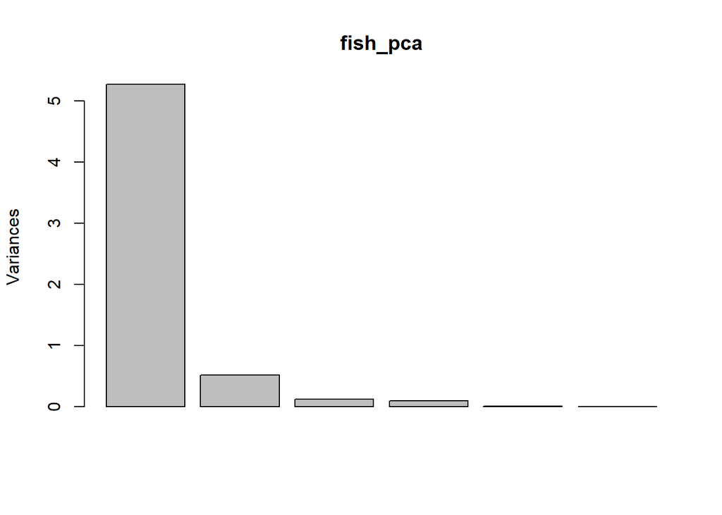

```r
plot(fish_pca)
```

```r
library(factoextra)
library(FactoMineR)
library(psych)
```

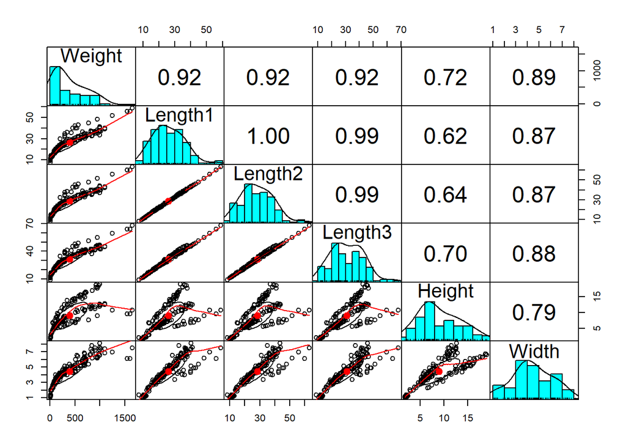

```r
library(corrplot)
library(devtools)
#correlation
pairs.panels(fish[,-1],
             gap = 0,
             bg = c("red", "blue")[fish$Species],
             pch=21)
```

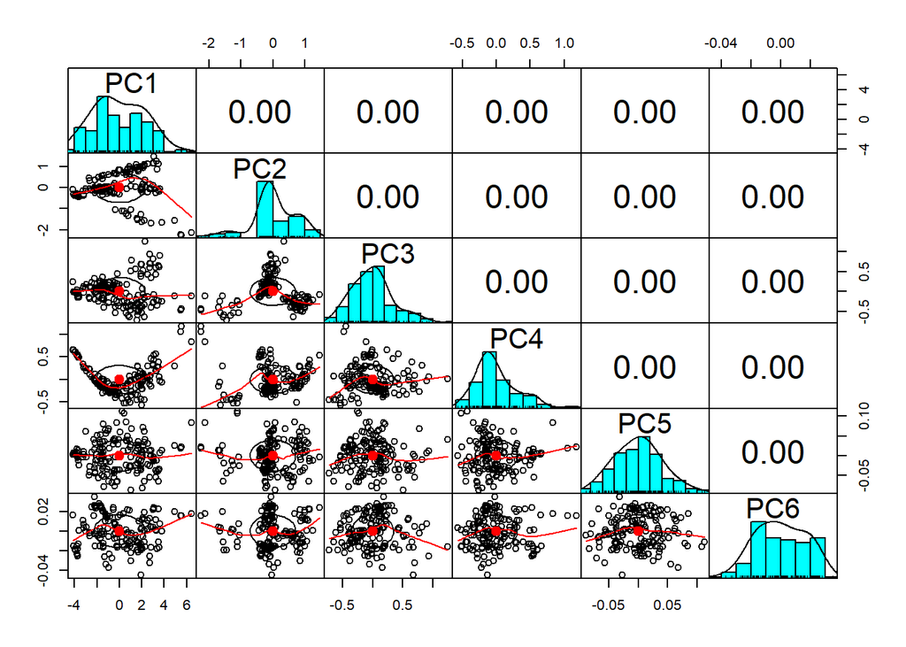

```r
pairs.panels(fish_pca$x,
             gap=0,
             bg = c("red", "blue")[fish$Species],
             pch=21)
```

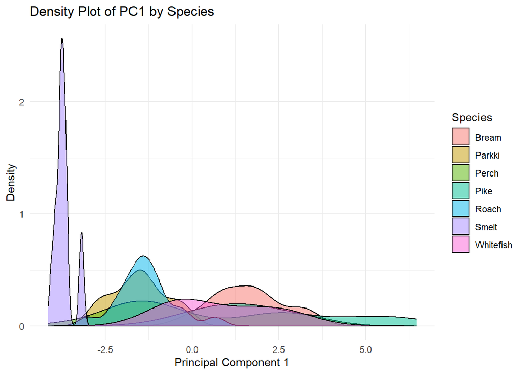

```r
ggplot(fishtype_pca, aes(x = PC1, fill = Species)) +
  geom_density(alpha = 0.5) +
  labs(x = "Principal Component 1", y = "Density", title = "Density Plot of PC1 by Species") +
  theme_minimal()
```

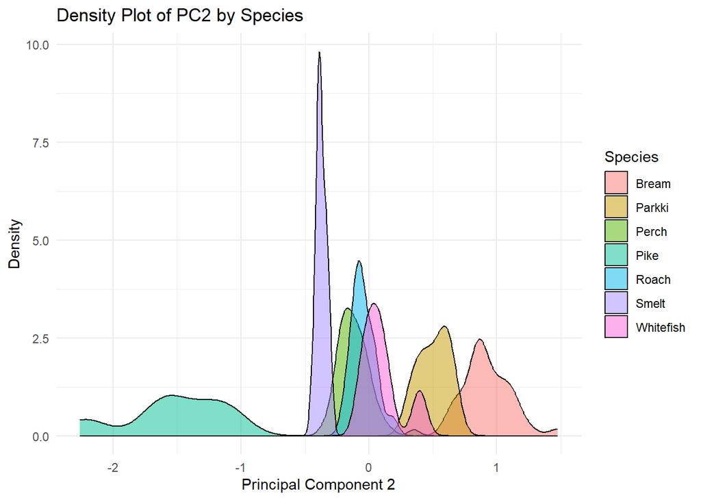

```r
ggplot(fishtype_pca, aes(x = PC2, fill = Species)) +
  geom_density(alpha = 0.5) +
  labs(x = "Principal Component 2", y = "Density", title = "Density Plot of PC2 by Species") +
  theme_minimal()
```

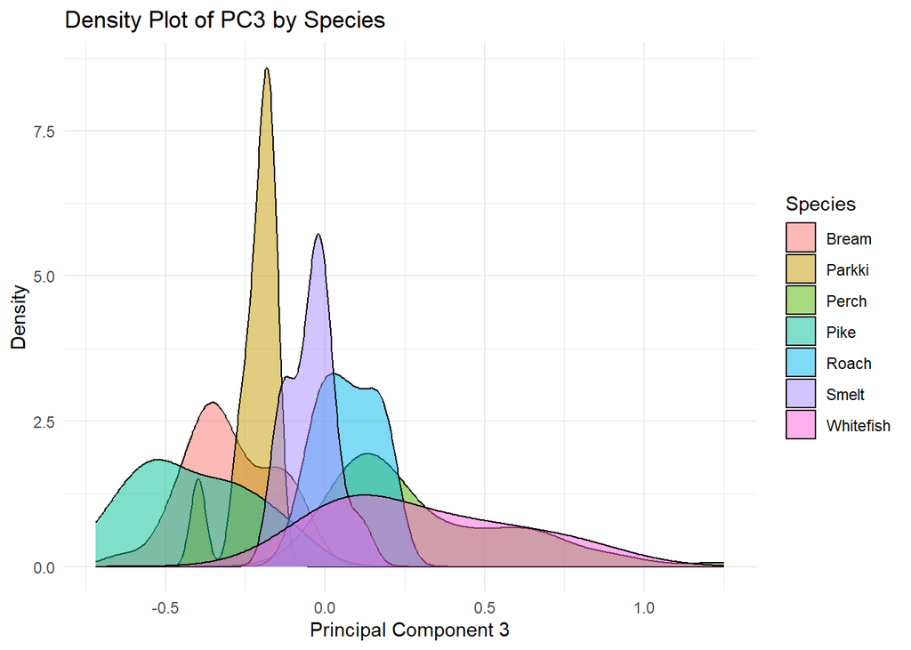

```r
ggplot(fishtype_pca, aes(x = PC3, fill = Species)) +
  geom_density(alpha = 0.5) +
  labs(x = "Principal Component 3", y = "Density", title = "Density Plot of PC3 by Species") +
  theme_minimal()
```

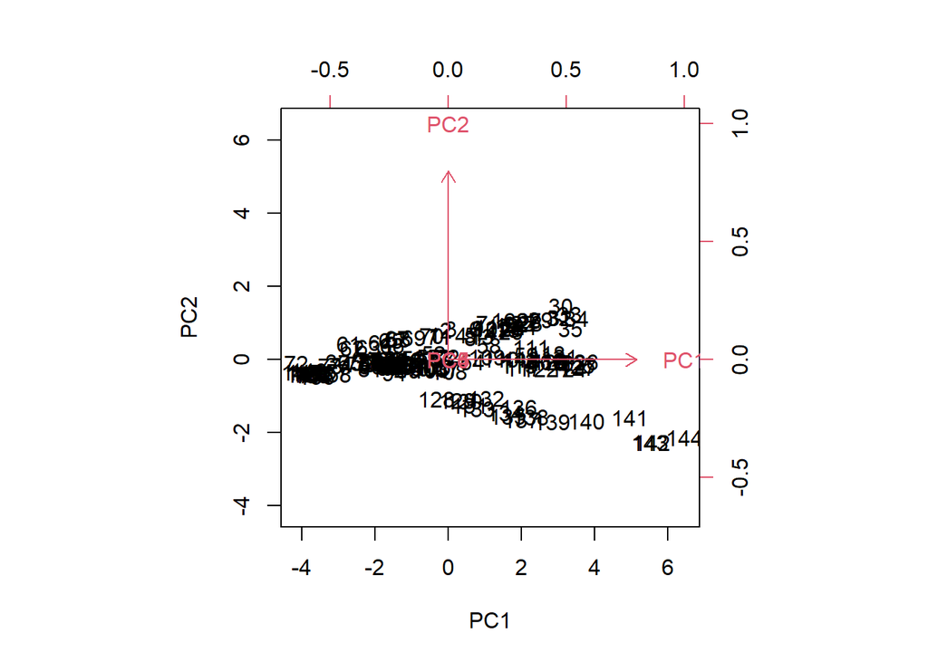

```r
biplot(prcomp(fishtype_pca[, -1]), scale = 0)
```

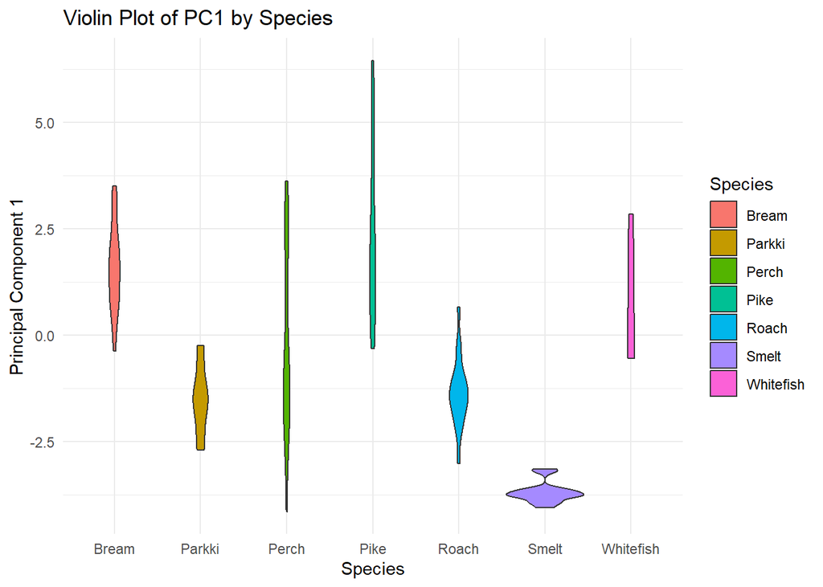

```r
ggplot(fishtype_pca, aes(x = Species, y = PC1, fill = Species)) +
  geom_violin() +
  labs(x = "Species", y = "Principal Component 1", title = "Violin Plot of PC1 by Species") +
  theme_minimal()
```

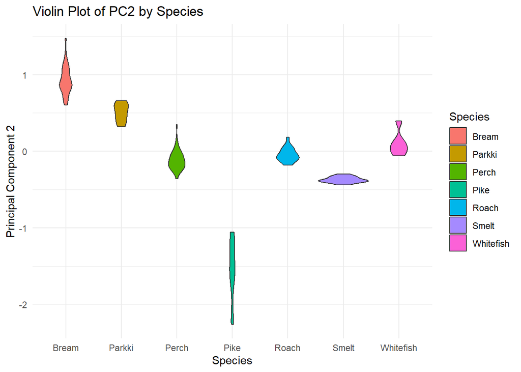

```r
ggplot(fishtype_pca, aes(x = Species, y = PC2, fill = Species)) +
  geom_violin() +
  labs(x = "Species", y = "Principal Component 2", title = "Violin Plot of PC2 by Species") +
  theme_minimal()
```

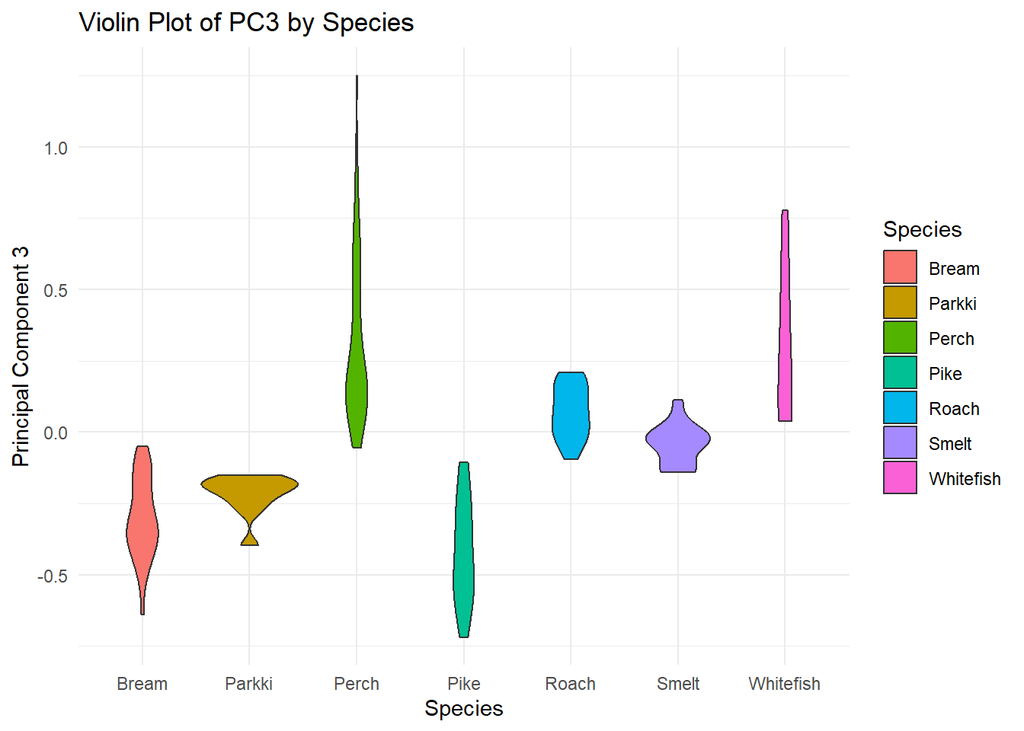

```r
ggplot(fishtype_pca, aes(x = Species, y = PC3, fill = Species)) +
  geom_violin() +
  labs(x = "Species", y = "Principal Component 3", title = "Violin Plot of PC3 by Species") +
  theme_minimal()
```